# Boilerplate Metrics

Amy Shuff

2023-04-18

# Growing Up Publications Indicators

POTENTIAL SHARED INDICATORS

- Median wages (number of households with children living below poverty line)
- Median rents (Number of children living in households with a high housing cost burden)
- Age-specific coverage rates for health insurance
- SNAP application and enrollment rates vs eligibility (for families with children; WIC focus?)
- Housing stability (mobility rates amongst children; include school mobility?)
- Trade school and other post-secondary opportunities
- Unemployment rates and other labor and employment metrics
- Reports of child abuse and neglect from CPS –poses a challenge
- Chronic absenteeism
- Test scores?
- Immigration/linguistic indicators
- Child care availability

EL PASO INDICATORS (August or November release)

- Number of immigrant children (C@R definition)
- Linguistic indicators?
- Other immigration specific indicators that highlight unique challenges posed to immigrant families
- Opportunity Youth focus UTEP Data for OY
- Food insecurity

SAN ANTONIO INDICATORS (Late September release)

- Child abuse indicators (needs building out)
- Poverty and intergenerational barriers (mentioned during the check in with san antonio, unsure how to measure this)
- Social community engagement with families/parents (mentioned during the check in with san antonio, unsure how to measure this)

# Child Care Desert Indicators

# Census Data Examples

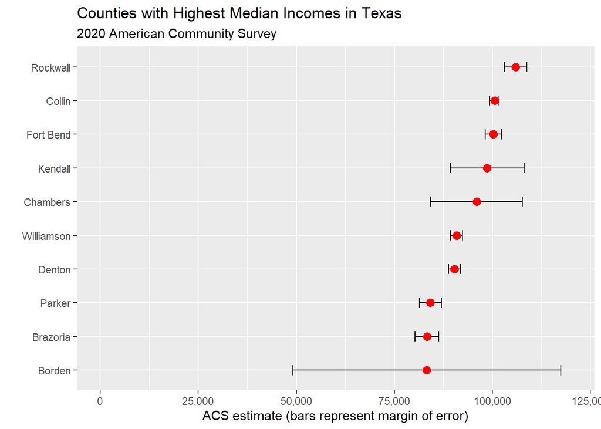

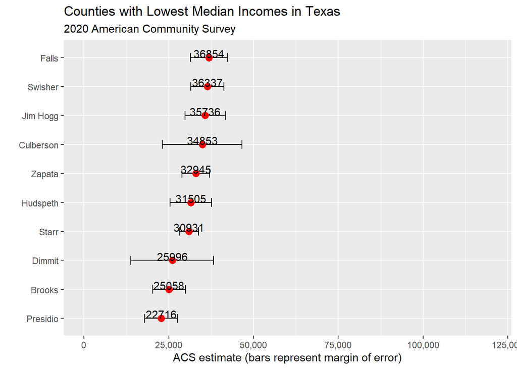

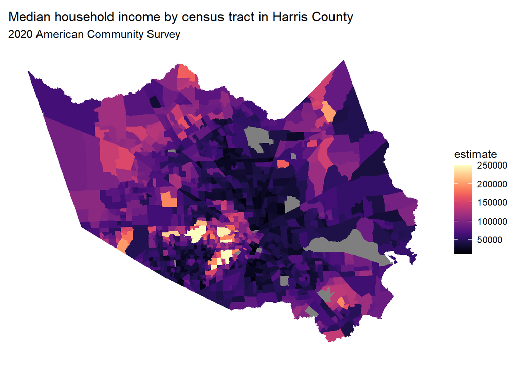

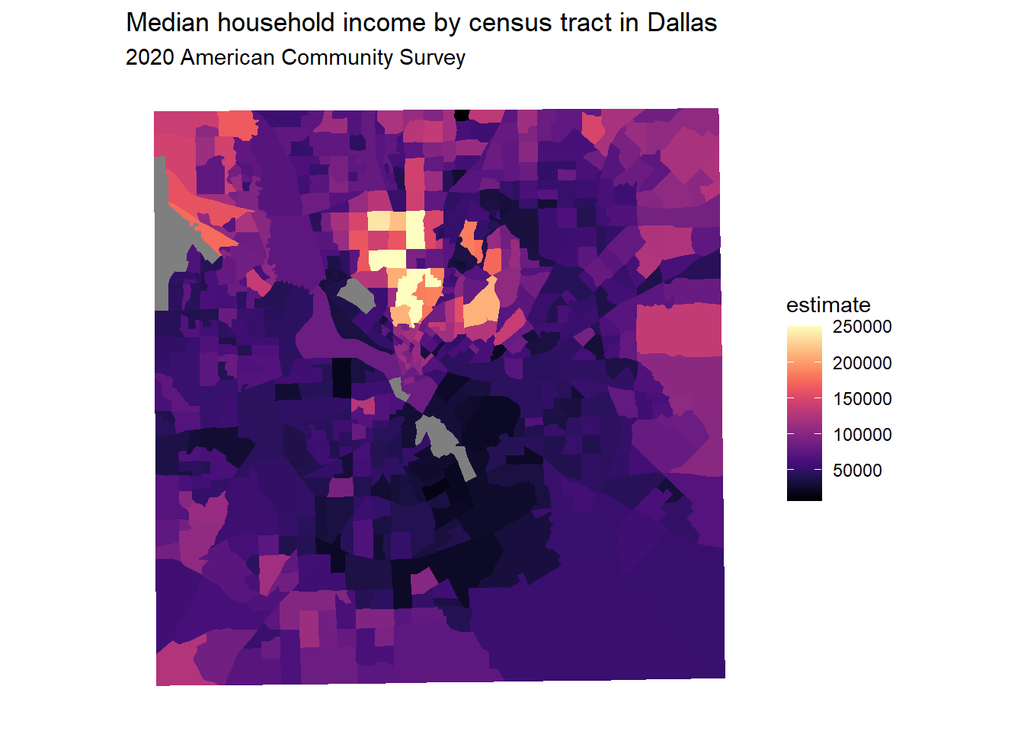

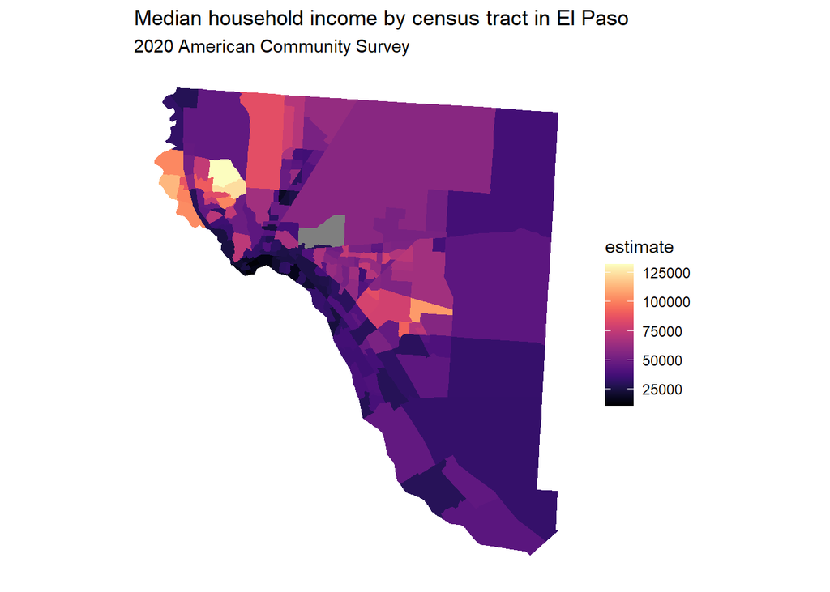

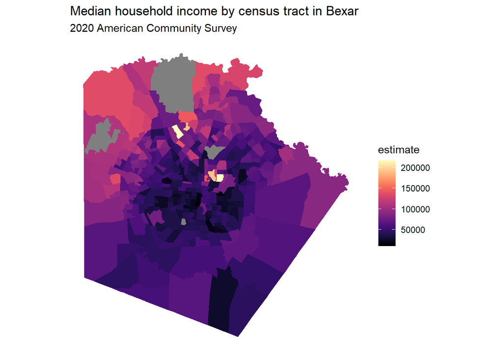

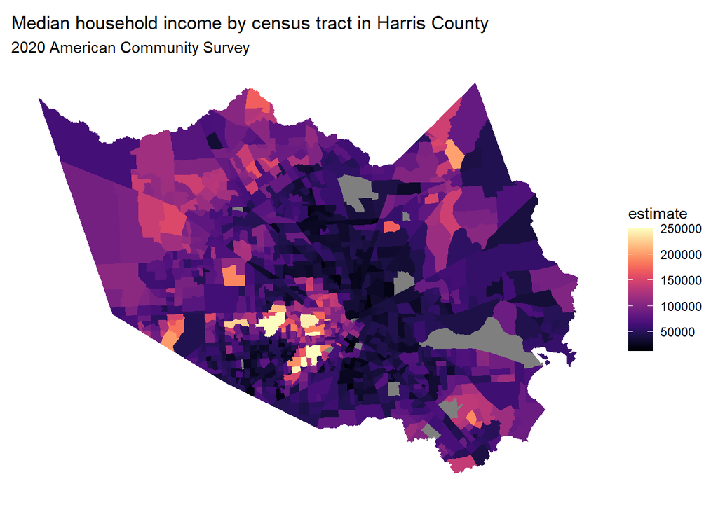

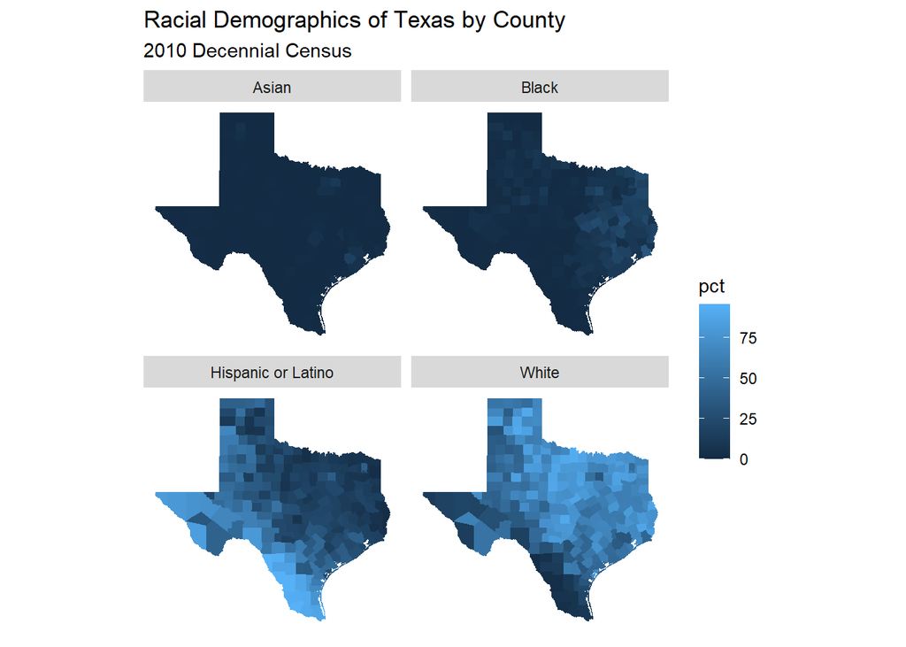

# Chat GPT Generated Code

Thought I would see if AI could help write code. It’s super buggy.